# Documentation of the extension of the fisheries composition dataset

Lucia Segovia de la Revilla

Thomas Codd

Liberty Mlambo

Louise Ander

04 November, 2022

## 0.1 SUMMARY

1. Identifying the data:

QC1: Evaluate the quality of the dataset and the documentation accompanying the dataset.

2. Importing the data into R: This step is going to depend on the original (raw) format.

QC2: We will ensure that all the data has been imported and done correctly. E.g., check that total number of observations and variables are correctly imported.

3. Tidying the data: This means we will convert from the original (raw) format to a standardised (harmonised) format, by performing all or some of the following operations:
1. Variable names: Components will be name using Tagnames (upper case) and the standard unit (lower case) (e.g., PROTg).
2. Dividing combined variables into two (or more) columns. E.g., `CARTEB or [CARTEBEQ]` into `CARTEBmg`, `CARTBEQmg`.
3. *Removing brackets* or other special characters (“[]”, “()”, “*”). E.g., extracting the numeric value from inside the bracket from “low quality”/alternative methods. –> How can we record/ account for it within the data?
4. *Removing summary stat from the table* –> How can we keep/use that data?
5. Food name/ description standardisation: For instance, for fisheries [ASFIS codes](https://www.fao.org/fishery/en/collection/asfis/en) will be assigned according to their species and fishery products.
6. Food groups variable (row to column).

QC3: Check that observations and variables are still the same as the original dataset, or in line with the previous operations performed, for instance, if we have divided a column into two, our dataset should have the same number of variables plus one.

4. Data transformation: Changes to the original data values will be performed and documented.
1. Changing characters into numeric. For example, trace (“tr”) or below detection limit (“<LOD”) will be converted into zero (0).
2. Changing variable units. For example from mg to g, according to the standard reporting units (FAO/INFOODS, 2013).
3. Combining or Re-calculating variables: Summary statistics will be calculated for each FAO ICP codes. For example, energy needs to be calculated from other components.
5. Visualising the data: missing values and outliers will be plotted and identified.
6. Exporting data and metadata

## 0.2 Background

The objective of this deliverable was to expand the preexisting Fisheries Global NCT for a rage of food components that are very relevant for fish. The initial list of food component that we evaluated for inclusion is shown in including the reason for inclusion or exclusion.

.: List of food components evaluated for the Fisheries Global NCT expansion.

[output not shown]

|6. | Vitamin B6 | Included | |

|7. | Vitamin B12 | Included ||

|8. | Vitamin D (including D3, D2 and hidroxi forms) | Excluded | here were not enough data () |

|9. | Docosapentaenoic acid (DHA) (22:6 (n-3)) | Included | |

|10.| Eicosapentaenoic acid (EPA) (20:5 (n-3)) | Included| |

### 0.2.1 1. Preparation steps: Identifying and accessing food composition data

#### 0.2.1.1 1. 1. Food composition tables for compiling the Fisheries Global Nutrient Conversion Table

Thirteenth Food Composition Tables and Databases (FCTs) were reviewed and included to generate a Global Nutrient Conversion Table (NCT). For the Fisheries Global NCT, two were excluded: uPulses FCT and the Composition of foods integrated dataset (CoFID). The later was excluded because it did not improve the data gaps, however it was process and it could be added in the future. The former was excluded for obvious reasons, as the data were not relevant for fisheries (i.e., only reported pulses).

Of the eleven FCT, three FCTs were not publicly available and, we requested access to the FAO Team. Access was granted and was covered by the data sharing agreement. In addition, because the FCTs included were previously reviewed by the FAO team, there was no need of checking the overall quality of the FCTs.

Then, we reviewed the availability of ten pre-selected food components: Copper, (Cu), Iodine (I), Selenium (Se), Vitamin B6 (Vit. B6), Vitamin B12 (Vit. B12), Vitamin D (Vit. D), Niacin, Docosapentaenoic acid (DHA), Eicosapentaenoic acid (EPA) (See ) in the 11 FCTs. Some data gaps were found for those components in the previously reviewed FCTs, hence we reviewed other possible sources of nutrient values (e.g. The Norwegian FCDB, 2021).

#### 0.2.1.2 1. 2. Identifying new potential sources of food components

We reviewed some FCTs that could provide information on fish and fishery products for the pre-defined nutrients of interest. Some potential candidates were FCTs of countries or region with potentially high consumption of fish: Ciqual FCDB (France), 2019, Norway FCDB, 2021, ASEAN FCDB, 2014.

When assessing quality and availability of data, we used the FAO/INFOODS framework (screening questions) to identify potential source of nutrient values. This led to the inclusion of the Norwegian FCDB, 2021. Because, it was the only new FCDB included which was not previously reviewed by the FAO team, we checked the original values of the Norwegian FCDB, 2021 (NO21) in depth, which is discussed in the **Section 2.1** of the protocol of the NO21.

In , we can find information on the final list of FCDBs included.

. List of all the FCTs included, and description of their access, format and reviewing team.

| BiblioID | Reference | Link to access original data | Access | Format | Reviewer |
| --- | --- | --- | --- | --- | --- |
| US19 | US Department of Agriculture (USDA), Agricultural Research Service, Nutrient Data Laboratory. USDA National Nutrient Database for Standard Reference, Legacy. Version Current: April 2019. | http://www.ars.usda.gov/nutrientdata | Publicly available | Access | FAO |
| AU19 | Food Standards Australia New Zealand (FSANZ). 2019. The Australian Food Composition Database, release 1 \[online\]. Canberra. | http://www.foodstandards.gov.au | Internal | excel | FAO |
| NZ18 | New Zealand Food Composition Database. 2019. New Zealand FOODfilesTM 2018 Manual. The New Zealand Institute for Plant and Food Research Limited and Ministry of Health. | http://www.foodcomposition.co.nz/foodfiles | Publicly available | excel | FAO |
| UK21 | Food Standards Agency. 2021. McCance and Widdowson’s The Composition of Foods Integrated Dataset (CoFID) 2021. London, Institute of Food Research, Public Health England. |  | https://www.gov.uk/government/publications/composition-of-foods-integrated-dataset-cofid | publicly available | excel |
| DK19 | Frida, DTU Foods public food database, version 4, 2019, National Food Institute, Technical University of Denmark. | https://frida.fooddata.dk | Publicly available | excel | FAO |
| WA19 | Vincent, A., Grande, F., Compaoré, E., Amponsah Annor, G., Addy, P.A., Aburime, L.C., Ahmed, D., Bih Loh, A.M., Dahdouh Cabia, S., Deflache, N., Dembélé, F.M., Dieudonné, B., Edwige, O.B., Ene-Obong, … | https://www.fao.org/fileadmin/user_upload/faoweb/2020/WAFCT_2019.xlsx | Publicly available | excel | FAO |
| KE18 | FAO & Government of Kenya. 2018. Kenya Food Composition Tables [online]. Nairobi. | http://www.kilimo.go.ke/wp-content/uploads/2018/10/KENYA-FOOD-COMPOSITION-TABLES-2018.pdf | Publicly available | excel | FAO |
| IN17 | Longvah, T., Ananthan, R., Bhaskarachary, K. & Venkaiah, K. 2017. Indian Food Composition Tables. Hyderabad, India, National Institute of Nutrition. | http://www.ifct2017.com/frame.php?page=home | Internal | excel | FAO |
| JA15 | MEXT. (2015).The Standard Tables of Food Composition in Japan 2015 (Seventh Revised Edition). Official Gazette Co-operation of Japan. Japan | http://www.mext.go.jp/a_menu/syokuhinseibun/1365451.htm/ | Publicly available | excel | FAO |
| BA13 | Shaheen N., Rahim A.T.M.A., Mohiduzzaman Md., Banu C.P., Bari Md. L., Tukun A.B., Mannan M.A., Bhattacharjee L., Stadlmayr B. 2013. Food Composition Table for Bangladesh. Institute of Nutrition and Fo… | https://www.fao.org/fileadmin/templates/food_composition/documents/FCDB_7_4_14.xlsx | Publicly available | excel | FAO |
| BR11 | Nucleo de Estudos e pesquisas em Alimentacao (NEPA). Brazilian Food Composition Table (TACO), 4th ed., 2011. | https://www.nepa.unicamp.br/taco/tabela.php?ativo=tabela | Internal | excel | FAO |
| UF16 | FAO. 2016. FAO/INFOODS Global Food Composition Database for Fish and Shellfish. Version 1.0 – uFiSh1.0. Rome. | http://www.fao.org/infoods/infoods/tables-and-databases/faoinfoods-databases/en/). | Publicly available | excel | FAO |
| UP17[^1] | FAO. 2017. FAO/INFOODS Global Food Composition Database for Pulses. Version 1.0 – uPulses 1.0. Rome. | http://www.fao.org/infoods/infoods/tables-and-databases/faoinfoods-databases/en/). | Publicly available | excel | FAO |
| NO21 | Norwegian Food Composition Database 2021. Norwegian Food Safety Authority. | https://www.matportalen.no/verktoy/the_norwegian_food_composition_table/ | Publicly available | excel | UoN |

## 0.3 Harmonisation of the food composition tables and databases (method)

The harmonisation required two main steps: importing (loading) databases into R and cleaning and standardising the databases.

### 0.3.1 1. Importing the data

Datasets were found in a variety of formats that needed to be imported and cleaned into a tabular format. E.g. one row per food entry and one column per variable (food entry attribute).

The steps and scripts for importing each FCDB are stored together with the original FCT (raw files) in individual folders named with the BiblioID (See table 1) which is stored in the variable `source_fct` (See table 2).

### 0.3.2 2. Tidying the data

In order to merge all data from various FCTs we needed to harmonise the information in each dataset. The steps that were taken are explained below and annotated scripts for each FCTs can be found in this repository in each corresponding folder.

#### 0.3.2.1 2.1. Renaming variable names

Each FCT has its own variable names, including for nutrient values. Some FCTs included information related to the FAO/ INFOODS food components identifiers [(Tagnames)](https://www.fao.org/infoods/infoods/standards-guidelines/food-component-identifiers-tagnames/en/)

while other did not. In order to merge all data from various FCDBs we need to harmonise the names of all the variables and particularly the food components of interest. To do so, we evaluated and renamed them with the most appropriate Tagname. Other variables (e.g., food id, food name or food description) were renamed to a common variable name, for instance, `fdc_id`, `food_desc`, following the variable names used in the Fisheries Global NCT file.

**The identification of food components**

Information on the food components and their description should be sought in each FCT included. We are reviewing the Tagnames used in the previous version for generating the same structure and format in our output table. Some minor changes in the variables names were introduced to be compliant with R conventions. E.g., removing spaces in variables names, changing symbols to characteres (e.g., µg to mcg), or standardising the name formatting from using underscores and/or parenthesis to using only underscores. Also, changing dashes (-) to underscores (_). Note that within the Tagnames, the dash is used to denote that the method for obtaining that (component) value is unknown. This is important for the quality assessment of the data.

Also, we also assumed that all the variables labelled as “standardised” were combined or recalculated variables

Table 2 provides a list of all the variables including components used in the previous version of the Fisheries Global NCT.

**Table 2.**: List of variables names (including Tagnames), description and reference for the Tagnames.

| Variable name | Description | Value type |
| --- | --- | --- |
| fdc_id | Food identifier as per original source (FCT) | Compiled |
| food_desc | Food name and description as per original source (FCT) | Compiled |
| food_group | Food group as per original source (FCT) | Compiled |
| scientific_name | Scientific name of the food | Compiled |
| source_fct | Id. of the FCT (BiblioID), see Table 1 | Generated |
| nutrient_data_source | References or data source for the nutrient values | Compiled |
| Edible_factor_in_FCT | Edible portion reported as fraction edible, imputed from the original FCT, or calculated from refuse in the FCT | Compiled |
| Edible_desc | Information provided on the edible portion | Compiled |
| specific_gravity | Density reported in the original units as in the original FCT | Compiled |
| SOPg | Sum of Proximate in g per 100g EP as reported in the original FCT | Compiled |
| SOPg_std | Sum of Proximate in g per 100g EP (Eq. 3.3) | Calculated |
| ASHg | Ashes in g per 100g of EP | Compiled |
| ASHg_std | Ashes in g per 100g of EP (Eq. 3.4) | Calculated |
| ENERCkJ | Energy in kJ/ 100g of EP as reported in the original FCT | Compiled |
| ENERCkJ_standardised | Energy in kJ/ 100g of EP (Eq. 3.5) | Calculated |
| ENERCkcal | Energy in kcal/ 100g EP as reported in the original FCT | Compiled |
| ENERCkcal_standardised | Energy in kcal/ 100g EP (Eq. 3.5) | Calculated |
| WATERg | Water/ moisture content in g per 100g of EP | Compiled |
| PROCNTg | Protein in g per 100g of EP, as reported in the original FCT and assumed to be calculated from nitrogen (NTg) content | Compiled |
| NTg | Nitrogen, total | Compiled |
| XN | Nitrogen conversion factor | Compiled |
| FATg | Total fat content in g per 100g of EP. Sum of triglycerides, phospholipids, sterols and related compounds obtained by a mixed solvent extraction | Compiled |
| FAT_g | fat content unknown method of calculation in g per 100g of EP | Compiled |
| FATCEg | Fat content measured using continuous extraction (e.g., Soxhlet method) expressed in g per 100g of EP | Compiled |
| FATg_standardised | Total fat content in g per 100g of EP regardless of the Tagname (and analytical method used). Including FATg, FAT_g and FATCEg. | Calculated |
| CHOAVLDFg | Available carbohydrates calculated by difference (E.g., 100 - (weight in grams of water + protein + fat + ash + fibre + alcohol in 100 g of food)) imputed from the original source | Compiled |
| CHOAVLg | Available carbohydrates calculated by weight in g per 100g of EP | Compiled |
| CHOCSMg | Carbohydrates, total; calculated by summation. This values is the sum of the sugars, starches, oligosaccharide, and dietary fibre in g per 100g of EP | Compiled |
| CHOAVLMg | Carbohydrates, available in monosaccharide equivalent. This value includes the free sugars plus dextrins, starch, and glycogen in g per 100g of EP | Compiled |
| CHOAVLDFg_std | Available carbohydrates calculated by difference (Eq. 3.6). | Calculated |

[output cut: 74 more lines]

#### 0.3.2.2 2.2. Other tidying operations

**a. Diving combined variables into two (or more) columns.** For example, when two components (Tagnames) were reported in the same column and identified using brackets ([]) around the component values. (`CARTEB or [CARTEBEQ]`) were separated into two independent columns and bracket removed (`CARTEBmg`, `CARTBEQmg`).

**b. Removing brackets or other special characters (“[]”, “()”, “*”)**. Similarly, special character were used to denote “low quality values” and/or alternative (determination) methods. For those cases, the numeric value was extracted and the special character removed. For future development, a way of keeping that information should be found (e.g, how can we record and account for those low quality values within the dataset?, can we generate a score with the number of “low quality” values per food item?).

**c. Removing summary statistics from the table.** Because summary statistics will not be used, data were removed. For future development, a way to account for variability (e.g., using the summary stats) could be studied (How can we keep/use that data?, could we use them to account for uncertainty in the final results?).

**d. Food name/ description standardisation.** The ASFIS list was used for identification of the fish and fishery products. The ISSCAAP and the 3-alpha codes were assigned to fishery products for identification and name standardisation. The ISSCAAP codes were also used for assigning the FAO ICP code. The FAO ICP code were extracted from previous work reported in Fisheries Global NCT, 2022, except for NO21 which was done semi-manually using R scripts (`NO21/NO21.R`) and it is reported in (`NO21/NO21_docu.Rmd`).

**e. Food groups variable.** Some food composition tables reported food groups that were placed as the first row of each category. Those rows were extracted and allocated as a new attribute of each food/fish entry (i.e., from row to new column (`food_group`)).

### 0.3.3 3. Data transformation

Some variables needed more than just renaming to allow comparison.

#### 0.3.3.1 3.1. Changing characters into numeric

To perform mathematical operations, characters needed to be converted into numeric operator. For instance, values that were reported to be trace (“tr”) or below the detection limit (“<LOD”) were converted to zero (0).

#### 0.3.3.2 3.2. Changing variable units

To standardise and merge the different FCTs, components needs to be reported in the same units. For example, some nutrients needed to be convert from mg to g, or from percentage (100%) to a fraction (1). For all the unit conversion we followed the FAO/INFOODS Guidelines for Converting Units, Denominators and Expression (FAO/INFOODS, 2012b), and the suggested standard reporting units.

Eg. Converting alcohol from weight in volume (w/v) to weight in mass.

**Eq.1** ALC (g/100mL) / density (g/mL) = ALC (g/100 EP)

Eg. amino acids (AA) reported per g in 100g of PROT to mg in 100g of EP:

**Eq.2.1** AA mg/100g EP = AA mg/g prot * prot g/100g EP /100

**Eq.2.2** AA mg/100g EP = AA g/ 100g prot * prot g/100g EP /100 * 1000/100

**Eq.2.3** AA mg/100g EP = AA g/100g prot * prot g/100g EP *10

**Eq.3.1** Edible portion = 100-Refuse (%)/100

**Eq.3.2** Edible portion = 1-Refuse

#### 0.3.3.3 3.3. Producing the harmonised data library

Once the FCTs were loaded and harmonised, we combined them into a single data file (data library), filter the fish entries and merged with the information already provided by the FAO team regarding each fish entry ISSCAAP, ICS FAOSTAT and alpha-three codes.

All the steps are done and documented in the `merging_all.R` script.

#### 0.3.3.4 3.4. Re-calculating variables

Some variables are calculated from other variables, hence they need to be recalculated to account for imputed values or when calculating mean concentration. Some of those are: Sum of proximate, Energy (kcal, kJ),or Carbohydrates available, by difference among others. Other variable that is often re-calculated is edible portion from refuse. There were special cases were back calculation from one or more food components were used to complete missing values. For example:

**Eq.4** Sum of Proximate (g/100g) = Sum of water + protein + fat + available carbohydrates + dietary fibre + alcohol + ash

**Eq.6a** Carbohydrates available by difference (g/100g) = 100 - (sum of water + protein + fat + ash + alcohol + dietary fibre)

**Eq.6b** Ash by difference (g/100g) = 100 - (sum of water + protein + fat + *available carbohydate* + alcohol + dietary fibre)

**Eq.7.1** Energy (kJ/100g EP): sum of protein (g/100g EP)*17 + available carbohydate (g/100g EP)*17 + fat(g/100g EP)*37 + alcohol (g/100g EP)*29 + dietary fibre (g/100g EP)*8

**Eq.7.2** Energy (kcal/100g EP): sum of protein (g/100g EP)*4 + available carbohydate (g/100g EP)*4 + fat(g/100g EP)*9 + alcohol (g/100g EP)*7 + dietary fibre (g/100g EP)*2

**Eq.8.1.**. Beta-Carotene eq. (mcg/100g) = 1*Beta-carotene (mcg/100g) + 0.5* Alpha-carotene (mcg/100g) + 0.5* Beta-cryptoxanthin (mcg/100g)

**Eq.8.2** Vitamin A, retinol eq. (RE) (mcg/100g EP) = Retinol (mcg/100g EP) + 1/6* Beta-Carotene eq. (mcg/100g EP)

**Eq.8.3** Vitamin A, retinol activity eq. (RAE) (mcg/100g EP) = Retinol (mcg/100g EP) + 1/12* Beta-Carotene eq. (mcg/100g EP)

.8.3a Retinol (mcg/100g EP) = Vitamin A, retinol activity eq. (RAE) (mcg/100g) - 1/12* Beta-Carotene eq. (mcg/100g EP)

#### 0.3.3.5 3.4. Combining Tagnames

Some food components could be reported using more than one Tagnames (as described in the renaming section and ). Of the fish-relevant nutrients selected for review some could be expressed using different Tagnames, depending on: the fraction analysed (e.g., Vitamin D3, Vitamin D2), or the method of analysis (e.g., VITB6A, VITB6C). When possible, they were standardised by combining values from similar Tagnames such as Vitamin B6 or total fat into a `_standardised` variable.

#### 0.3.3.6 3.5. Imputing values

Data imputation was avoided whenever it was possible (i.e., when mean value for each ICS SUA fishery categoies were available (n=>1). In the cases when this condition was not met, a case-by-case approach was taken and it was documented here (See ) and in the final Fisheries Global NCT (see `comment`).

##### 0.3.3.6.1 Generating functions for data transformation

**Special values**: We generated a function (`no_brackets_tr`) to be called to change trace and below the detection limit values to zero, and to remove brackets (see functions.R).

**Combining variables**: The variables `VITB6_mg_standardised`, `FAT_g_standardised` and `THIAmg_std` were generated by using a function.

**Calculating variables**: For instance, Vitamin A, retinol eq.(mcg/100g) and Beta-Carotene eq.(mcg/100g) were calculated using a function for the weighted sum of the listed variables. Including one of the special cases, for instance, `RETOLmcg_Recalculator()` was used to fill up retinol missing values by back-calculation from Vitamin A (RAE) and Beta-Carotene equivalent.

Here’s the list of the standardised variables as reported in the Fisheries Global NCT, 2022 (Feb., 2022), of which all except food folate (FOLDFEmcg) were reported and calculated by functions developed to generate them in the Fisheries Global NCT, 2022 (Oct., 2022).

- SOP_own = Sum of Proximate
- ENERCkJ_standardised
- ENERCkcal_standardised
- CHOAVLDFg_standardised
- FAT_g_standardised
- FIBTGg_standardised
- VITAmcg_standardised
- VITA_RAEmcg_standardised
- CARTBEQmcg_standardised
- VITEmg_standardised
- THIAmg_standardised
- FOLDFEmcg_standardised*
- VITB6_mg_standardised
- NIAEQmg_standadised
- NIATRIPmg_standardised
- VITDmg_standardised

### 0.3.4 4. Data visualisation

#### 0.3.4.1 4.1. Checking Tagnames for completeness

We checked the number of missing values per food component using data visualisation. We used the *package naniar*((**ref-naniar?**)) for visualising missing values by ICS SUA fishery category and by FCT. This allowed us to identify any typos or mistakes when renaming the food components, and also to identify potential food components that could be excluded due to the high number of missing values. Similarly the need for using imputation techniques (see & ).

#### 0.3.4.2 4.2. Checking quality of the values

We used histograms and boxplot to identify extreme values by plotting the different components by fish type and fish preparation. These two variables were created for data visualisation purposes and did not make it to the final dataset: Fisheries Global NCT (Oct., 2022).

### 0.3.5 5. Exporting data and metadata

All these steps would allow to replicate the process and to re-generate the table with the same format for future updates.

#### 0.3.5.1 5.1. Formatting the data

After all the values were evaluated, particularly the mean values of each food component per ICS SUA category, the data library was formatted to be exported into a human-friendly format (e.g. Excel).

First, a summary row was generated for each ICA SUA category which contained the final mean value for each food component of interest. Additionally, some food components were recalculated at the summary row.

### 0.3.6 Nutrient to be calculated at the summary row:

1. SOP own
2. Energy (kcal)
3. Energy (kJ)
4. Carbohydates by difference (g)
5. Vitamin A RAE (mcg)
6. Vitamin A RA (mcg)

Finally, information was added regarding the ICS SUA fishery categories description and edible portion were added from the previous version to the generate the Fisheries Global NCT.

### 0.3.7 6. Updating Fisheries Global NCT

Final adjustment were carried to mantain the format of the previous version of the Fisheties Global NCT.

# 1 Results

### 1.0.1 1. Importing FCTs

Of the thirteen FCTs previously identified, the UP17 was not processed because it did not contain information for fisheries, three FCTs were not publicly available and, we requested access to the FAO Team (). Access was granted and was covered by the data sharing agreement. In addition, because the FCTs included were previously reviewed by the FAO team, there was no need of checking the overall quality of the FCTs. One new FCT was added to the final selection of FCTs (NO21) which provided information on fisheries, including information on DHA and EPA.

Hence, we extracted information on all the components available in the 12 FCTs, however particular attention have been given to the following: Cu, I, Se, Vit. B6, Vit. B12, Vit. D, Niacin, DHA, EPA, as the were not reviewed in the previous version of the Fisheries Global NCT.

### 1.0.2 2. Tidying the data

The data cleaning operations were done by individual annotated R scripts for each FCT and were stored, together the raw data (raw FCT files), in a folder with its biblioID (See ). Details on the operations and decisions made during the data cleaning are presented in subsequent sections.

#### 1.0.2.1 2.1. Renaming variables

Food component names and descriptions were examined in each FCT and renamed with the corresponding Tagnames.

Some FCTs reported the food components using the Tagnames which were checked, extracted and used to rename the food components. Tagnames were found in different formats, hence some name harmonisation was still needed.

- In the AU19, it was expressed as part of the variable name. “Moisture (water) (WATER) (g)”, being the Tagname `WATERg`.
- Similarly, in the IN17 which was obtained from the sharing agreement with the FAO team, the Tagnames were available in the FCT and complemented with the FCT documentation [REF]. Note that a great number of organic acids were reported (Table 9, from column 123), of which very few Tagnames were available.
- In the JA15, Tagnames were also self-contained in original FCT file. However, manual renaming of some components, as it was done for the IN17, was needed. For instance, “Protein, calculated from reference nitrogen_g” to `PROCNTg`, “Lipid_g” to `FATg`, and “Carbohydrate, total, calculated by difference_g” to `CHOAVLDFg`.
- In KE18, Tagnames were also self-contained in the original database and also have been previously reviewed for the MAPS project. Only small fixes were needed to be adapted for this project (i.e., adding the units along the Tagnames or filtering columns that were mostly empty (FA)).
- In WA19, Tagnames were provided and, as for KE18, has been previously reviewed and pre-processed for MAPS. Note that the edible portion is divided into two variables: “EDIBLE1” and “EDIBLE2”, we are using “EDIBLE1” as the `Edible_factor_in_FCT` variable following FAO Fisheries Global NCT, 2022.
- In BR11, Tagnames were provided by the FAO team as it was previously processed. Hence, only renaming of the information variables (e.g., “food id” = fdc_id) was needed.
- In UF16, it included Taganames and we only needed to rename “Edible coefficient, from whole to fillet/flesh (EDIBLE1)” to `Edible_factor_in_FCT`, following what was reported in the FAO Fisheries Global NCT, 2022,and as it was done in WA19.

For others datasets included, Tagnames were not reported and they needed to be generated using the information reported in the Fisheries Global NCT, 2022, and the documentation accompanying each FCT.

- In the DK19 documentation [REF](https://frida.fooddata.dk/pdf/en-frida-2-introduction_20-12-2016-esax.pdf), we found that the variable named as “vitamin A (RE)” was in reality the Vitamin A RAE, and hence the corresponding Tagname was `VITA_RAEmg`, similarly “vitamin D” was `VITDEQmg`, according to DK19 documentation and FAO/INFOODS, 2012.
- In NZ18, renaming was manually done. Information about Vit. D was insufficient to certainly know the Vit. D fraction reported in the FCT.
- In the UK21, Tagnames were added manually. In addition, some things that were noted were: Alcohol was reported as volumen (Alcohol (ALC) g/ mL (w/v)). We did not transformed the units because: 1) alcohol was not included as one of the NVs to be reviewed and, 2) we finally did not include this FCT into the final Fishery Global NCT, 2022. However, for the future, if we want to change to match the 100g EP values, we could re-calculate ALC variable by using Eq.1 and the density of each food which is provided in the FCT (specific_gravity). Vitamin D was renamed to `VITDmg`, however re-calculation using D3 and 25-hydroxy D3 values would be recommended when possible. Finally, for the DHA and EPA, we used cis- version, but it should be reviewed. This was based on the documentation available in the Composition of Foods integrated dataset: PHE (Public Health England) (2021) Composition of foods integrated dataset (CoFID). Available at: https://www.gov.uk/government/publications/composition-of-foods-integrated-dataset-cofid (accessed 28/03/2022).
- In the US19, renaming was also done manually and based on the documentation and the information provided in the Fisheries Global NCT, 2022. We identified the Tagnames in one of the attached files, hence for the future a comparison/ update using those Tagnames could be done.
- In BA13 we renamed the variables to the Tagnames manually, Vitamin E (reported as “VITE”) definition was not clear and hence, in future should be checked.
- In NO21, variables were manually renamed to the Tagnames. This was included for this project hence a more in-depth review of each component was needed and it is described in the **Section X.X of the NO21 documentation**

#### 1.0.2.2 2.2. Other tidying operations

##### 1.0.2.2.1 Removing parentheses and brackets

In JA15, parentheses were used to denote “estimated values”. According to JA15 documentation, those were used to “Composition values estimated based on values listed in the food composition tables of foreign countries, raw material blending ratio recipe, etc. are indicated by placing them in parentheses. For some of Cereals, Fruits and Mushrooms, composition values derived from estimation or calculation using the listed values of similar foods are indicated by placing them in parentheses.” (REF).

In KE18, brackets (“[]”) denoting not preferred values, as for the KE18 reporting: “For alternative analytical method or lower quality. Data from non-preferred Tagnames were presented only where preferred Tagnames data was not available.” (REF).

Bracket for low quality values were removed or generated a new column with the alternative analytical method for UF16, WA19 and KE18. In addition, for the later, a star (“*”) was used to identify items fortified with folic acid. Note some issues on the reporting of this fortification were found previously, however the data was not reviewed in-depth because folate and related food components were outside the scope of this work. When we removed the brackets, for future development accounting for the impact of the “estimated values” should be studied.

##### 1.0.2.2.2 Food groups

Each FCT has its own food groups, for instance in some FCTs were useful for identifying fishery and fishery products. For instance in UK21 fisheries were divided into five food groups: “White fish (JA)”, “Fatty fish (JC)”, “Crustacea (JK)”, “Molluscs (JM)”, and “Fish products and dishes (JR)”. The id (`fcd_id`) could be used as well to identify as all fisheries, as all started with “16”.

### 1.0.3 3. Transforming values

#### 1.0.3.1 3.1. Characters in nutrient values

Trace and/or below detection limit were reported and converted to zero in the following FCTs: IN17 (“<LOD”), BA13, BR11, JA15 (“Tr”), and KE18, UK21, and WA19 (“tr”).

Characters and symbols were used to report missing values were “nv” in DK19, “-” in JA15, and “M” in NO21 which were all transformed to `NA`. Similarly, nutrients present in significant quantities (not trace), but without reliable information on the amount, were reported in UK21 as “N” which were converted to `NA`.

#### 1.0.3.2 3.2 & 3.3. Unit conversions and re-calculation

Some components were reported in different units as the recommended units in the Tagnames, hence unit conversion operations were performed. For instance:

In the IN17, fatty acids needed to be converted from mg/100g EP to g/ 100g EP, and amino acids from g/100g PROT to mg/100g EP (Eq.2.3).

Similarly, in JA15, we need to change the unit of the fatty acids from mg to g, and the edible portion was calculated from refuse (Eq.3.1).

Moreover, when (substantial) changes, like those mentioned above, were made to the values reported in the original FCT, documentation was done on GitHub so future users could review our decisions:

Documentation in GitHub

[Issue\#9](https://github.com/LuciaSegovia/UoN-FAO/issues/9), [Issue\#10](https://github.com/LuciaSegovia/UoN-FAO/issues/10).

#### 1.0.3.3 3.3. Merging all the data together

Once the FCTs were loaded and harmonised, we combined them into a single data library.

###### 1.0.3.3.0.1 3.3.1. Allocating the FAO codes: ISSCAAP, alpha-three, and ICS FAOSTAT.

Fish matching between FCTs fish entries and ICS FAOSTAT, alpha-three code and ISSCAAP code was previously done in the Fishery Global NCT, 2022. Hence, we used that information to generate a dataset which contained information for each fish entry about ISSCAAP, ICS FAOSTAT and alpha-three codes (“ics-code_fish-code.csv”). The dataframe `ics_code_file` contained the information in the following variables: `ICS.FAOSTAT.SUA.Current.Code`, `source_fct`, `NDB_number`, `fdc_id`, `Food.description`, `Scientific.name`, `ISSCAAP.Group`, and `X3.alpha.code`.

Minor adjustment were needed, for instance, the food id of KE18 in the Fishery Global NCT, 2022 were as in the “original” (raw) KE18 (e.g., “0807”). In order to match the KE18 ids. in our dataset, we removed the first “0” (e.g., “807”). For the US19, we needed to change the `fdc_id` to `NDB_number`. Then, we merged `ics_code_file` (the dataset derived from Fishery Global NCT, 2022) and the newly Fisheries nutrient table (`fish_fct`) by each fish entry id. (`fdc_id`). That operation resulted in a dataset with all the fishery products and its corresponding ICS FAOSTAT code, alpha-three code and ISSCAAP code.

The UK21 was excluded from the Fishery Global NCT, 2022 hence ICS FAOSTAT code were not available for the fish in that FCT.

After all the merging operations, only fish with information on ICS code were kept, hence, around 318 fish entries were filtered out, mainly from UK21 but some from NO21 as well

#### 1.0.3.4 3.4. Combined variables (standardised)

After merging and filtering the fishes, and before calculating the mean nutrient values of each ICS FAOSTAT fishery category some variables needed to be recalculated and/or standardised.

Here’s the list of the standardised variables as reported in the Fisheries Global NCT, 2022, the following:

- SOP_own
- ENERCkJ_standardised
- ENERCkcal_standardised
- CHOAVLDFg_standardised
- FAT_g_standardised
- FIBTGg_standardised
- VITAmcg_standardised
- VITA_RAEmcg_standardised
- CARTBEQmcg_standardised
- THIAmg_standardised
- VITB6_mg_standardised
- NIAmcg_standardised

In addition, two special cases are reported here: ASHg_std and RETOLmcg, which were both recalculated. All of which used functions that were generated to re-calculate the variables using the equations in the section 3.3 of this document and can be found in “functions.R”.

##### 1.0.3.4.1 3.4.1. Sum of proximate (SOP)

Sum of proximate was not reported by all FCTs. Therefore, it was re-calculated using the equation reported in the methods section ((**eq-5?**)). Additionally, it was calculated at ICS (SUA) fish category level.

Sum of proximate (=Σof water + protein + fat + available carbohydrates + dietary fibre + alcohol + ash)

Ranges: Preferable: 97 - 103g (Greenfield and Southgate, 2003, FAO/INFOODS, 2012)). Acceptable: 95 - 105g (FAO/INFOODS, 2012))

##### 1.0.3.4.2 3.4.2. Energy

Of the nutrients used to calculate energy, the most important for fish and fish products are proteins, fat, water and carbohydrates. Hence, the review of those components should be carried more in-depth than the other, fibre, and alcohol could be assumed zero, for most of fish and shellfish products, with the exceptions of preparations, canned, cured and/or molluscs (FAO/INFOODS, 2012).

We will generate a function that will calculate energy in kcal and energy in kj using the FAO conversion factors and the fao tagnames that will be used to generate the columns: `ENERCkJ_standardized` and `ENERCkcal_standardized` for the FAO fishery products database and for MAPS to calculate energy used.

##### 1.0.3.4.3 3.4.4. Carbohydrates by difference

Carbohydrates by difference were calculated using the Eq.6a. In NO21, the value of ash (g/100g EP) used were calculated. In addition, we found 38% of negative values of carbohydrates by difference which were converted to zero and added a comment “CHOAVLDFg_std assumed zero” for documentation.

The documentation of these changes are important as they would have an impact of the final estimates, particularly as this variable is used to calculate SOP, and more importantly the total energy. If total energy is calculated using negative values it would lead to a underestimation of the total energy supplied by the foods.

##### 1.0.3.4.4 3.4.3. Fat

We combined three Tagnames into `FAT_g_standardised` as reported in section 3.4. We checked the contribution from each of the fractions Table 1.1.

Table 1.1: The table present the percentage of each fat tagname contribution to the total.

| FATg | FAT_g | FATCEg | FAT_g_standardised |
| --- | --- | --- | --- |
| 78.82 | 7.33 | 13.85 | 100 |

##### 1.0.3.4.5 3.4.3. Ash

Ash values were reported in all FCTs but the NO21 which was calculated from the carbohydrate by difference equation (Eq.3.4b). Full information was reported elsewhere (NO21_docu.Rmd). We combined `ASHg` (reported in the FCTs) and `ASHg_bydiff` into one variable `ASHg_std`.

##### 1.0.3.4.7 3.4.3. Vitamin A (RE) and (RAE)

These two variables were re-calculated using the function `VITAmcg_std_creator()` and `VITA_RAEmcg_std_creator()` which used the variables `RETOLmcg` and `CARTBEQmcg_std` as inputs.

##### 1.0.3.4.8 3.4.3. Beta-Carotene equivalents

This was a calculated variable, hence when possible (i.e, when the carotenoids were reported), re-calculation was preformed using the function `CARTBEQmcg_std_creator()` and stored in the variable `CARTEBEQmcg_std`. This ensures that we avoid propagation of error across data sources. However, this was not always possible hence some values were extracted from the Beta-Carotent Eq. (`CARTEBEQmcg`) from the FCTs, and other were back calculated from the retinol and Vitamin A (RAE) as described in the method section 3.4.

Some constrains of using this back-calculation was that there were some cases where retinol was greater that Vitamin RAE, this affected to 19 fisheries entries, but were only 7 unique fisheries entries. We then transformed negative values to zero, assuming that if Vitamin A was smaller than the retinol value, then no carotene would be presented.

##### 1.0.3.4.9 3.4.3. Retinol

Retinol should be provided by the FCT, and ideally it would be analyised. However, there were some cases that retinol was missing, however values for Vitamin A and Beta-Carotene eq. were provide. Therefore, we used the function `RETOLmcg_Recalculator()` to re-calculate the missing values. Additionally, the function add the documentation (i.e., “RETOLmcg value re-calulated from VITA_RAEmcg and CARTBEQmcg” or “RETOLmcg value re-calulated from VITA_RAEmcg and VITAmcg” in the `comment`). Again, this is important to 1) identify data gaps, and 2) flagging potential issues with the data.

##### 1.0.3.4.11 3.4.3. Thiamine

Thiamine was combined into the Thiamine standardised variable (`THIAmg_std`) using the function `THIAmg_std_creator()` as reported in the method section 3.4.

##### 1.0.3.4.12 3.4.3. Niacin

Niacin (`NIAmg`) was reported in all FCTs but in WA19, in which niacin equivalent (`NIAEQmg`) was reported. Because tryptophan was reported in the WA19, `NIAmg` was re-calculated into a new variable and combined into the Niacin standardised variable (`NIAmg_std`) using the function:`nia_conversion_creator` as reported in the method section 3.4.

## 1.1 REVIEW

##### 1.1.0.0.1 4. Visualising food components for decision-making

After standardising and recalculating the variables, and before calculating the mean nutrient values of each ICS FAOSTAT fishery category, we visualised the data (e.g., data availability) and performed quality check for the nutrient values of interest (Cu, I, Se, Niacin, Vit.B6, Vit. B12, Vit. D, DHA, EPA). Visualisation scripts are reported in `visualisation.R` and quality check are reported in `QC.R`.

###### 1.1.0.0.1.1 4.1. Nutrient avaibility for Fisheries Global NCT extension

We evaluated the availability of ten nutrients to extend the Fisheries Global NCT. In figure 1 (**fig-1?**), we can see that Cu and Vit. B6 were reported by all FCTs but KE18, with overall very high data availability with very few missing values. In contrast, I and Vit. D were reported only in six FCTs, and DHA and EPA were in seven.

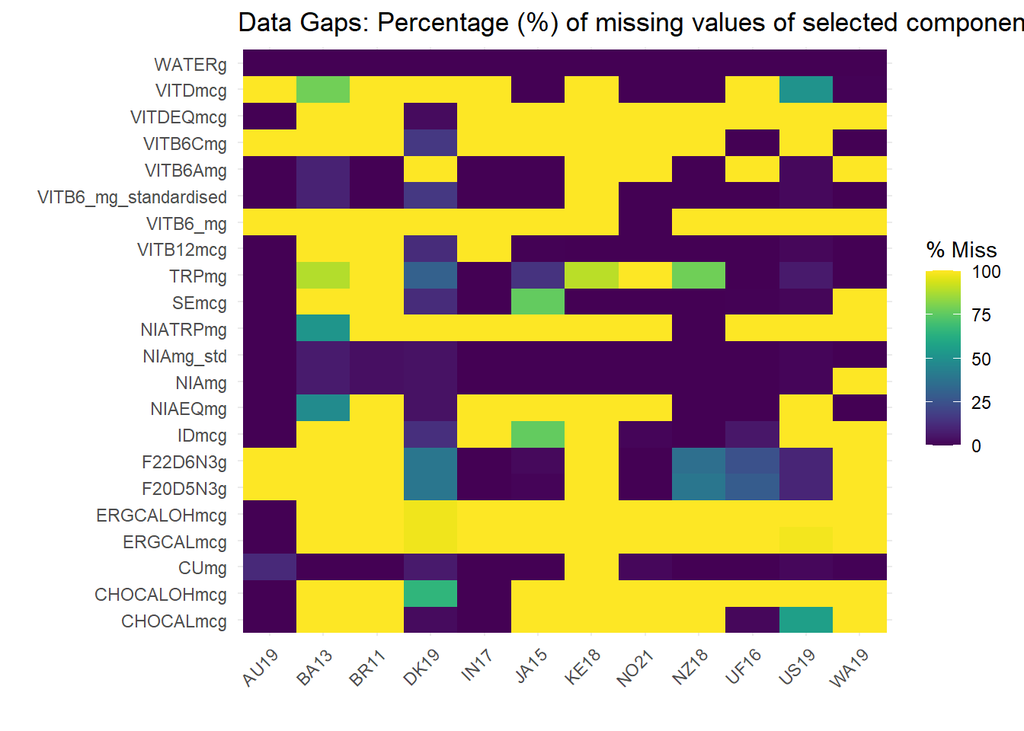

Figure 1.1: Figure 1: Percentage of missing values per component and food composition table.

**Figure 1: Percentage of missing values per component and FCT**

However, some FCTs contributed to the overal NCT with more fisheries entries, hence we checked the overall availability as percentage of the overall fisheries entries. In figure 2, we can see that Cu, Vit. B6 and niacin had high coverage with more than 75% of the fish entries reporting a value for those components. While for DHA, EPA and Se had a moderate coverage with over 60% of the fish entries reporting a value. Finally, vitamin D and I were excluded from the extension.

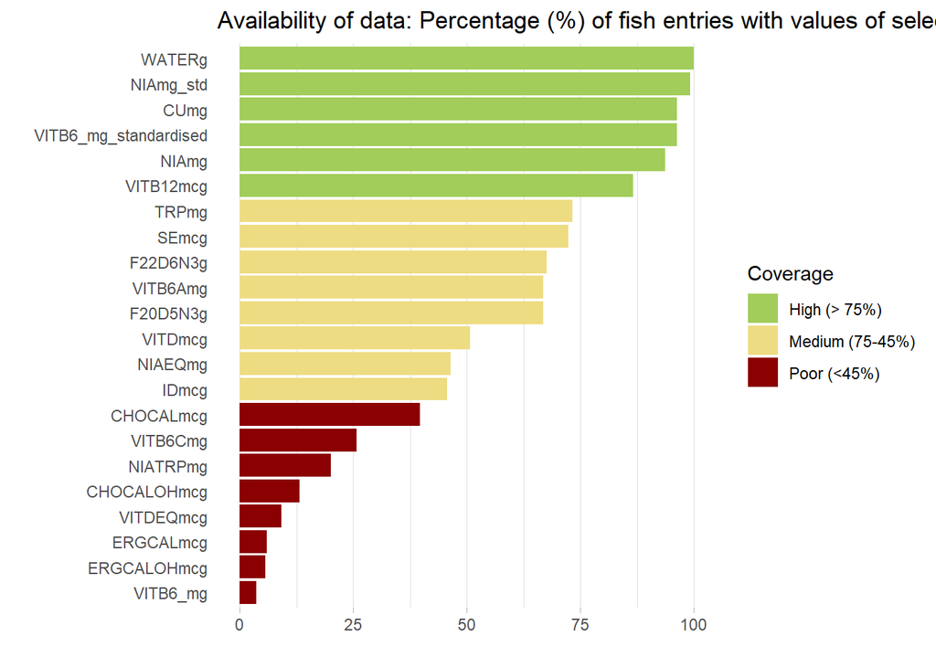

Figure 1.2: Figure 2: Coverage: Percentage of reported values per component.

**Figure 2: Coverage: Percentage of reported values per component**

###### 1.1.0.0.1.2 4.2. Data avaibility per each ICS FAOSTAT fish category

**Table 3: Count of values per component and SUA fish category**

| WATERg_sd | Fish categories | Water | WATERg_mean | VITB6_mg_standardised_sd | Vitamin B6 | VITB6_mg_standardised_mean | VITB12mcg_sd | Vitamin B12 | VITB12mcg_mean | SEmcg_sd | Selenium | SEmcg_mean | NIAmg_std_sd | Niacin | NIAmg_std_mean | F22D6N3g_sd | DHA | F22D6N3g_mean | F20D5N3g_sd | EPA | F20D5N3g_mean | CUmg_sd | Copper | CUmg_mean |
| --- | --- | --- | --- | --- | --- | --- | --- | --- | --- | --- | --- | --- | --- | --- | --- | --- | --- | --- | --- | --- | --- | --- | --- | --- |
| 8.0018477 | Marine fish nei, preparations nei | 294 | 68.51377 | 0.2057658 | 282 | 0.2512466 | 4.3318013 | 279 | 3.6166720 | 22.4094142 | 207 | 48.7909637 | 4.8116667 | 294 | 4.6379324 | 0.4758821 | 183 | 0.4735683 | 0.3213784 | 184 | 0.2699946 | 0.0481543 | 278 | 0.0625000 |
| 6.1184412 | Demersal fish, preparations nei | 248 | 71.30860 | 0.1387765 | 242 | 0.2051635 | 2.7049770 | 235 | 2.3056788 | 22.6412083 | 204 | 42.7448224 | 3.8879579 | 248 | 3.0740129 | 0.2123450 | 177 | 0.2527684 | 0.1812963 | 178 | 0.1512584 | 0.0348555 | 240 | 0.0434769 |
| 9.2716224 | Freshwater & diadromous fish, preparations nei | 241 | 66.40929 | 0.1979465 | 228 | 0.3211568 | 4.5824698 | 231 | 4.4278547 | 13.1298609 | 185 | 29.2992272 | 2.5306406 | 241 | 4.5071415 | 0.6514476 | 144 | 0.6431736 | 0.3797163 | 138 | 0.3523841 | 0.0963085 | 227 | 0.0778279 |
| 3.9031909 | Demersal fish, frozen, whole | 155 | 77.22155 | 0.1255704 | 153 | 0.2150948 | 1.6618006 | 108 | 2.0495833 | 17.0060016 | 109 | 35.6850459 | 1.6290396 | 155 | 2.8976710 | 0.2240360 | 146 | 0.2573797 | 0.1677885 | 146 | 0.1442649 | 0.1274783 | 154 | 0.0598117 |
| 3.8782813 | Demersal fish, fresh | 154 | 77.17818 | 0.1255721 | 152 | 0.2142730 | 1.6664766 | 107 | 2.0593925 | 17.0763603 | 108 | 35.7376852 | 1.6304184 | 154 | 2.9067468 | 0.2240360 | 146 | 0.2573797 | 0.1677885 | 146 | 0.1442649 | 0.1278970 | 153 | 0.0598105 |
| 5.2060325 | Marine fish nei, frozen, whole | 154 | 74.60268 | 0.1921811 | 148 | 0.3282767 | 3.9622441 | 149 | 3.9480201 | 19.0642399 | 85 | 43.0105882 | 4.4513048 | 154 | 5.3778763 | 0.3942152 | 131 | 0.4400000 | 0.2862790 | 131 | 0.2651832 | 0.0430631 | 149 | 0.0558630 |
| 5.1680442 | Marine fish nei, fresh | 153 | 74.54192 | 0.1928356 | 147 | 0.3281969 | 3.9682056 | 148 | 3.9679392 | 19.1248624 | 84 | 43.1654762 | 4.4547604 | 153 | 5.4032219 | 0.3942152 | 131 | 0.4400000 | 0.2862790 | 131 | 0.2651832 | 0.0432080 | 148 | 0.0558350 |
| 5.9377744 | Marine fish nei, frozen fillets | 139 | 75.91182 | 0.2248067 | 138 | 0.2187908 | 2.6440502 | 136 | 1.9433915 | 20.2580993 | 122 | 43.6081665 | 3.2715091 | 139 | 3.6341603 | 0.5227392 | 89 | 0.4231573 | 0.2692553 | 86 | 0.1840814 | 0.0510586 | 138 | 0.0537232 |
| 5.8970632 | Marine fish nei, fresh fillets | 136 | 75.74819 | 0.2268084 | 135 | 0.2192084 | 2.6642269 | 133 | 1.9760995 | 20.4676899 | 119 | 43.6487086 | 3.2773419 | 136 | 3.6984433 | 0.5281450 | 87 | 0.4275517 | 0.2720098 | 84 | 0.1865833 | 0.0514429 | 135 | 0.0541985 |
| 5.7115013 | Freshwater & diadromous fish, frozen, whole | 129 | 73.64114 | 0.1930853 | 124 | 0.2794577 | 2.8105078 | 83 | 4.6321084 | 15.2134467 | 78 | 27.9200000 | 2.5428965 | 127 | 3.7856935 | 0.5053213 | 88 | 0.4697214 | 0.3455864 | 88 | 0.2790869 | 0.2561478 | 125 | 0.1050128 |
| 5.7274873 | Freshwater & diadromous fish, fresh | 127 | 73.60580 | 0.1912750 | 122 | 0.2840390 | 2.8105078 | 83 | 4.6321084 | 15.2134467 | 78 | 27.9200000 | 2.5496721 | 125 | 3.8126646 | 0.5053213 | 88 | 0.4697214 | 0.3455864 | 88 | 0.2790869 | 0.2582354 | 123 | 0.1051810 |
| 5.9225896 | Crustaceans, preparations nei | 116 | 74.47762 | 0.0730457 | 114 | 0.1144923 | 3.1525127 | 114 | 3.9549668 | 23.5129707 | 100 | 47.2052151 | 0.9058019 | 116 | 2.3465879 | 0.0488973 | 59 | 0.0825424 | 0.0799962 | 53 | 0.1221509 | 0.5467453 | 113 | 0.8575710 |
| 8.8703296 | Diadromous fish, preparations nei | 116 | 61.78608 | 0.2092081 | 110 | 0.4322123 | 5.1486861 | 111 | 5.1941028 | 12.1608427 | 96 | 28.6624461 | 2.4511315 | 116 | 6.1378052 | 0.6373706 | 70 | 1.1029571 | 0.3897100 | 70 | 0.5814429 | 0.1235165 | 110 | 0.0927095 |
| 6.1993035 | Freshwater fish, preparations nei | 114 | 71.39258 | 0.1032341 | 107 | 0.2094430 | 4.0215296 | 109 | 3.8210003 | 13.9934787 | 79 | 31.2754708 | 1.2044325 | 114 | 2.8748746 | 0.1420338 | 63 | 0.1563175 | 0.0828818 | 57 | 0.0724912 | 0.0595998 | 107 | 0.0652233 |
| 8.3948006 | Pelagic fish, preparations nei | 103 | 62.53900 | 0.2714284 | 97 | 0.3756905 | 5.3821478 | 101 | 6.7526432 | 29.0856953 | 60 | 56.0464286 | 4.5854468 | 103 | 7.2475429 | 0.5843266 | 63 | 0.9102063 | 0.4119965 | 63 | 0.5105556 | 0.0496640 | 95 | 0.1043214 |
| 4.7150172 | Pelagic fish, fresh | 98 | 72.69554 | 0.2417205 | 94 | 0.3508026 | 4.7202673 | 64 | 6.9609375 | 26.2384058 | 75 | 46.1040000 | 5.0313365 | 98 | 6.6385097 | 0.4517974 | 83 | 0.5751652 | 0.3499140 | 83 | 0.3049580 | 0.0578963 | 94 | 0.0765381 |
| 4.7150172 | Pelagic fish, frozen, whole | 98 | 72.69554 | 0.2417205 | 94 | 0.3508026 | 4.7202673 | 64 | 6.9609375 | 26.2384058 | 75 | 46.1040000 | 5.0313365 | 98 | 6.6385097 | 0.4517974 | 83 | 0.5751652 | 0.3499140 | 83 | 0.3049580 | 0.0578963 | 94 | 0.0765381 |
| 3.1158893 | Crustaceans, frozen | 89 | 78.94691 | 0.0777932 | 81 | 0.1420247 | 2.9554711 | 70 | 3.4833968 | 15.5567267 | 71 | 42.0113090 | 1.0304840 | 82 | 2.2667255 | 0.0414910 | 46 | 0.0587004 | 0.0546892 | 43 | 0.0776665 | 0.3277910 | 88 | 0.6187439 |
| 3.9250732 | Demersal fish, frozen, fillets | 89 | 78.61173 | 0.0906645 | 88 | 0.1396723 | 0.8360313 | 88 | 1.0864913 | 15.8329127 | 84 | 38.4130514 | 1.0591981 | 89 | 2.3332296 | 0.2849235 | 59 | 0.2635593 | 0.1201847 | 59 | 0.1020169 | 0.0330812 | 88 | 0.0399812 |
| 3.0143344 | Crustaceans, fresh | 88 | 79.03721 | 0.0782199 | 80 | 0.1416750 | 2.9619635 | 69 | 3.4477939 | 15.6682445 | 70 | 42.0300420 | 1.0344545 | 81 | 2.2589073 | 0.0344353 | 45 | 0.0552049 | 0.0500698 | 42 | 0.0741110 | 0.3296899 | 87 | 0.6188444 |
| 3.8874510 | Demersal fish, fresh fillets | 86 | 78.44714 | 0.0896050 | 85 | 0.1375431 | 0.8404270 | 85 | 1.1074263 | 16.0275174 | 81 | 38.2802015 | 1.0274742 | 86 | 2.3895050 | 0.2904202 | 57 | 0.2646667 | 0.1223311 | 57 | 0.1028246 | 0.0334322 | 85 | 0.0402511 |
| 5.9992550 | Freshwater & diadromous fish, frozen fillets | 85 | 74.48209 | 0.1907991 | 81 | 0.2879554 | 2.6655394 | 68 | 3.1084869 | 12.9270907 | 60 | 25.8280093 | 2.9314537 | 85 | 3.6165307 | 0.5466339 | 36 | 0.4736389 | 0.2775476 | 33 | 0.2338182 | 0.0815428 | 81 | 0.0723784 |
| 4.2060382 | Molluscs, excluding cephalopods, fresh | 82 | 81.29829 | 0.0695062 | 82 | 0.0914139 | 14.3328430 | 77 | 16.7597542 | 25.9033265 | 63 | 40.8555794 | 0.4013675 | 82 | 1.5961348 | 0.0881101 | 49 | 0.1011633 | 0.1004792 | 49 | 0.1209529 | 1.1342410 | 82 | 0.6835438 |
| 4.2243402 | Molluscs, excluding cephalopods, frozen | 81 | 81.32666 | 0.0697839 | 81 | 0.0919252 | 14.3631929 | 76 | 16.9144878 | 26.0881026 | 62 | 40.7080887 | 0.4024191 | 81 | 1.5923834 | 0.0890423 | 48 | 0.1011875 | 0.1013793 | 48 | 0.1201394 | 1.1355658 | 81 | 0.6709949 |
| 5.8791039 | Freshwater & diadromous fish, fresh fillets | 79 | 74.05253 | 0.1882666 | 75 | 0.3041829 | 2.6794383 | 64 | 3.2425069 | 12.6747900 | 56 | 26.9145337 | 2.9997164 | 79 | 3.7217630 | 0.5573442 | 32 | 0.5272187 | 0.2820180 | 29 | 0.2653448 | 0.0817503 | 75 | 0.0719998 |
| 8.4620410 | Pelagic fish, canned | 75 | 64.44057 | 0.4792830 | 74 | 0.4204189 | 4.0452841 | 73 | 5.8493151 | 29.3675579 | 48 | 58.3375000 | 3.8097241 | 75 | 8.4481956 | 0.5708847 | 60 | 0.7845833 | 0.4747916 | 60 | 0.4958833 | 0.0700270 | 73 | 0.1117235 |
| 9.2993766 | Small pelagic fish, preparations nei | 72 | 62.17787 | 0.2643248 | 69 | 0.3429273 | 5.4524750 | 70 | 6.7982423 | 18.4852128 | 40 | 55.4696429 | 2.9487855 | 72 | 5.8429387 | 0.5973190 | 43 | 1.0368837 | 0.4324344 | 43 | 0.6046977 | 0.0493130 | 67 | 0.1141871 |
| 8.4878609 | Marine fish nei, canned | 67 | 64.86347 | 0.5046614 | 66 | 0.4279242 | 4.2704995 | 65 | 5.7515385 | 19.0787153 | 40 | 57.7825000 | 3.8845066 | 67 | 8.4734279 | 0.5189990 | 51 | 0.7248627 | 0.4696224 | 51 | 0.4658235 | 0.0731317 | 65 | 0.1143510 |
| 3.6900828 | Freshwater fish, frozen, whole | 62 | 76.01495 | 0.1463777 | 61 | 0.1996354 | 3.2308839 | 23 | 3.8719565 | 17.9646470 | 24 | 26.2825000 | 1.9395917 | 61 | 2.3626242 | 0.1161762 | 29 | 0.1489903 | 0.0942272 | 29 | 0.1000497 | 0.0854845 | 62 | 0.0818420 |
| 5.0441851 | Small pelagic fish, fresh | 61 | 73.19115 | 0.1668529 | 58 | 0.2642915 | 5.0374198 | 35 | 7.4711429 | 16.1466135 | 46 | 39.1986957 | 3.3719901 | 61 | 4.8261467 | 0.4402312 | 53 | 0.5896257 | 0.3483452 | 53 | 0.3354032 | 0.0615448 | 59 | 0.0801797 |

[output cut: 65 more lines]

For **Cephalopods, cured**, we used the water-adjusted Se mean concentration of the items reported in table 4 to “complete” the Se concentration of the following “Cephalopods, cured”:

[1] “Mollusks, firefly squid, seasoned and smoked”  
[2] “Mollusks, processed squid,”Surume” dried squid”  
[3] “Mollusks, processed squid,”Saki-ika” dried, seasoned and shredded squid”  
[4] “Mollusks, processed squid, seasoned and smoked”

**Table 4**. Cephalopods used to impute Se values for “cephalopods, cured”

| fcd_id | food_desc | WATERg | SEmcg | source_fct |
| --- | --- | --- | --- | --- |
| 10342 | Mollusks, neon flying squid, raw | 79.3 | 28 | JA15 |
| 10345 | Mollusks, Japanese common squid, raw “Syn. short-finned squid” | 80.2 | 41 | JA15 |

For **Cephalopods, canned**, there was only one item under that category: *“Mollusks, Escargot Apple snails, canned in brine”*. However that item should be recorded under “Molluscs, excluding cephalopods”, according to the description in the documentation (REF). Hence, to populate this SUA category, we decided to use the cephalods entries from “preparations nei”, which were described as “boiled/ moist heat” (n=22) (table 5). This was decided based on:

1. The description of *Cephalopods, Canned* in the FAO documentation, which is >“Raw or precooked meat from gutted or ungutted animals, canned in brine, oil or other medium (all edible) treated at temperatures adequate to ensure sterilization. Examples are: vacuum-packed small octopus, canned squid in own ink or oil.”. >
2. Nutrient values reported on the Spanish FCT [ref] for “squids, fresh” and “squids, canned” were very similar. Unfortunately, there was no information for Se.
3. Same fish type would have more similar composition, despite the cooking method, than a different fish, particularly when they are divided into distinct SUA categories.
4. In addition, when perfect match is not possible the mean of several foods is recommended over a single food match (FAO/INFOODS, 2012).

**Table 5**: List of cephalopods imputed to generate the “Cephalopods, canned” SUA category.

| fdc_id | food_desc | WATERg | SEmcg | source_fct |
| --- | --- | --- | --- | --- |
| F006146 | Octopus, boiled, no added fat | 78.10 | 49.80 | AU19 |
| 10362 | Mollusks, common octopus, boiled | 76.20 | 28.00 | JA15 |
| 04.302 | Squid, boiled | 75.00 | 116.00 | NO21 |
| 093062 | Inshore squids, flesh, boiled | 61.02 | 76.50 | UF16 |
| 093097 | Inshore squids, flesh, boiled in recipe | 61.02 | 85.00 | UF16 |
| 093063 | European squid, flesh, boiled (n.s.) | 61.10 | 93.12 | UF16 |
| 093098 | European squid, flesh, boiled in recipe (n.s.) | 61.10 | 100.00 | UF16 |
| 093064 | European squid, wild, flesh, boiled (Mediterranean Sea) | 59.66 | 46.41 | UF16 |
| 093099 | European squid, wild, flesh, boiled in recipe (Mediterranean Sea) | 59.66 | 51.57 | UF16 |
| 093065 | Octopuses, etc., flesh, boiled | 67.26 | 82.79 | UF16 |
| 093100 | Octopuses, etc., flesh, boiled in recipe | 67.26 | 91.99 | UF16 |
| 093066 | Common octopus, flesh, boiled (n.s.) | 67.28 | 95.09 | UF16 |
| 093101 | Common octopus, flesh, boiled in recipe (n.s.) | 67.28 | 110.00 | UF16 |
| 093067 | Common octopus, wild, flesh, boiled (Mediterranean Sea) | 67.57 | 95.09 | UF16 |
| 093068 | Ommastrephidae squids, flesh, boiled | 60.04 | 89.74 | UF16 |
| 093103 | Ommastrephidae squids, flesh, boiled in recipe | 60.04 | 99.71 | UF16 |
| 093069 | Cuttlefish, bobtail squids, flesh, boiled | 62.31 | 86.66 | UF16 |
| 093104 | Cuttlefish, bobtail squids, flesh, boiled in recipe | 62.31 | 96.29 | UF16 |
| 093070 | Common cuttlefish, flesh, boiled | 61.77 | 86.66 | UF16 |
| 093105 | Common cuttlefish, flesh, boiled in recipe | 61.77 | 96.29 | UF16 |
| 15229 | Mollusks, cuttlefish, mixed species, cooked, moist heat | 61.12 | 89.60 | US19 |
| 15230 | Mollusks, octopus, common, cooked, moist heat | 60.50 | 89.60 | US19 |

NOTE: There are some concerns related to the edible portion, for instance in fish described as “canned”, we are assuming that all content is edible, and hence of the 100g of canned squid, X% would be squid and Y% medium (e.g., sauce, oil, etc.). This is not captured by boiled which is assuming 100% edible squid.

For **Aquatic animals, nei, cured and preparation nei**, when we checked the items included in these two categories, there were mostly Sea urchin, jellyfish, sea cucumber and sea squirt from the JA15.

However, when we reviewed the fish entries with Se values included in the “Aquatic animals, nei, fresh” category, we realised that it was very diverse category, including from crocodiles to sea cucumber. The only Se information that was available and comparable was for sea cucumber, thus we water-adjusted the Se concentration of: “Sea cucumber, raw” (`WATERg` = 92.2, `SEmcg` = 37) for imputing the Se concentration in:

[1] “Sea cucumber,”Konowata” salted and fermented viscera”  
[2] “Sea urchin,”Tsubu-uni” salted whole gonads”  
[3] “Sea urchin,”Neri-uni” salted whole gonad paste”  
[4] “Jellyfish, Salted, desalted”  
[5] “Sea squirt,”Shiokara” salted and fermented meat and viscera (Syn. Ascidian)“

For **Crustaceans, cured**, we needed to impute Se concentration for “Crustacean, Sakura shrimp, dried”, for which we used (10415) “Crustacean, whiteleg shrimp, raw” (`WATERg` = 78.60, `SEmcg` = 27). And, for “Shrimp (crayfish), whole, dried”, we calculated mean of the values reported in table 6. These values were selected based on:

1. They were the same fish item: Shrimp (crayfish).
2. UF1(092004) value was reported in the references “Shrimp (crayfish), whole, dried”.

**Table 6**: List of fish entries used to imputed to Se concentration for “Shrimp (crayfish), whole, dried”.

| fdc_id | food_desc | WATERg | SEmcg | source_fct |
| --- | --- | --- | --- | --- |
| 092001 | European/Euro-American/Oceanian crayfishes, flesh, raw (n.s.) | 81.87 | 41.48 | UF16 |
| 092002 | European/Euro-American/Oceanian crayfishes, wild, flesh, raw (n.s.) | 82.18 | 31.60 | UF16 |
| 092003 | European/Euro-American/Oceanian crayfishes, farmed flesh, raw | 84.10 | 28.40 | UF16 |
| 092004 | Palaemonid shrimps, flesh, raw | 77.16 | 31.21 | UF16 |

Finally, values were not adjusted for any retaining factor as according to Vásquez-Caicedo et al. (2008) and Bognar (2002), retention factors for Se are between 0.9-1, with dry heat (braise, fry in oven, broiling, grilling) being 1.

Information regarding the values used to impute/calculate the `SEmcg` for the items can be found in the column `comment`.

###### 1.1.0.0.1.3 4.2. Data quality per each ICS FAOSTAT fish category

###### 1.1.0.0.1.4 4.2.1. Niacin

We check for “extreme values”, and after plotting the values, we identified some potential “extreme values”. However after comparing these values with similar fish product, all the values seemed plausible. For example, one of the high value was smoke-dried and fermented fish (i.e., low water concentration). When the niacin concentration was compared on dry-weight basis concentration with similar fresh items, the niacin concentration was similar.

Note that for “Other pelagic fish, cured”, one of the high values had a great influence in the final mean value. For instance, when we removed values that were higher than 40mg/100g, the mean of that SUA category was 15mg/100g instead of 30mg/100g (range:15-45mg/100g). This could be solved by including more fish entries (more values) for that fish category, as currently there are only two entries for that category.

The rest of the SUA categories remained more or less the same.

###### 1.1.0.0.1.5 4.2.2. Copper

Similarly for Cu, we identified items that had the highest values: Octopus from IN17 (fdc_id = R003) which looked very high, even when compared with other octopus values. Double-check the value.

Oyster from UF16 (fdc_id = 093013) also seems high compared with other oyster but seems plausible given the type of food. For instance, of the 10 items with the highest Cu concentration, 4 were oyster.

Another item from the JA15 (fdc_id = 10350) was also extremely high, however when we compared it with the “fresh” values, it was still in line with the water content of that item. However, because the item was driving the very high mean for the category “Cephalopods, cured”, (mean = 3.38) we decided to remove it from the final mean, which yielded more nuanced value (mean = 0.51). For future, and in order to minimise the influence of this type of food items, more values should be sought for each category.

###### 1.1.0.0.1.6 4.2.3. Vitamin B6

After combining the values of the three Tagnames into one Vitamin B6 (standardised), it was reported in all but one FCT (KE18). Overall, values were within plausible values. The highest values reported were for Tuna and they were still within normal ranges.

###### 1.1.0.0.1.7 4.2.4. Vitamin B12

Vitamin B12 was reported in nine FCTs. JA15 seemed to report higher values than the other FCTs, including most of the high-end values.

We found that “Molluscs, excluding cephalopods, frozen”, “Molluscs, excluding cephalopods, fresh”, and “Molluscs, excluding cephalopods, canned” had the highest Vit. B12 values. We found that clams from JA15 had the highest values for the “Molluscs, excluding cephalopods, frozen”. However, when we plotted the data it seemed to have a normal distribution, and hence we are not considering them as outliers.

The category “Cephalopods, preparations nei” have very high variability, it seemed that octopus had higher Vit.B12 than other cephalopods in the category, also most of the high values were sourced from UF16, while the highest was from US19. It maybe that the UF16 values were imputed from US19.

###### 1.1.0.0.1.8 4.2.5 DHA

Of the seven FCTs that reported DHA, some extreme values could be seen in the US19 and DK19 with values higher than 5g of DHA.

When we checked those extreme values, all of them (values >4g of DHA per 100g of EP) were reported in oils, hence they seemed plausible values. For the other values higher than the 4th quantile, most corresponded to fish and preparation with high fat content (>5%) ((**ref-infoods?**)) and contained relatively low water content (<70%) ((**ref-infoods?**)).

However when we checked the percentage of difference between fat content of the items with DHA values and without, some concerning differences were shown. This was particularly true for very heterogeneous SUA categories were also limited number of items were included, for instance, “Aquatic mammals, meat”, “Aquatic animals nei, fresh”. We could not find values for DHA for those items in literature or other FCTs, hence this remained as an area were improvements are needed.

“Aquatic plants, dried”, there are many `NA`, however, for those that values are available DHA is zero. Maybe we could “assume zero” for those values.

###### 1.1.0.0.1.9 4.2.6. EPA

Results of the EPA checks were very similar to those for DHA.

###### 1.1.0.0.1.10 4.2.7. Selenium

When we checked the values one value, “Tuna, raw” (04.043) from the NO21, seemed very high compared with other tuna values. There were other high values but they seemed to be still within plausible ranges.

| fdc_id | food_desc | WATERg | SEmcg |
| --- | --- | --- | --- |
| 04.043 | Tuna, raw | 74.0 | 200 |
| 04.043 | Tuna, raw | 74.0 | 200 |
| 04.055 | Crab, boiled | 72.0 | 200 |
| 04.107 | Tuna, in oil, drained, canned | 58.0 | 186 |
| 04.333 | Sashimi, tuna | 74.0 | 200 |
| T39 | Lobster, cooked | 74.6 | 130 |

When we checked by SUA category, we identified the “Other pelagic fish, cured” which had the highest mean value,only two fish entries and only one Se value. Similarly, “Aquatic mammals, preparations nei” only reported information for three entries of which only two had a `SEmcg` value.

Similarly, the “Aquatic mammals, meat”, only 3 have Se values out of 15 fish entries. Although, the mean value is on the higher end of the Se values, it is difficult to assess whether the value is a good representation of the category due to the due to the lack of data availability.

For future improvement, we could use imputation technique to the overall mean of these SUA categories.

###### 1.1.0.0.1.11 Other components

The addition of the NO21 involved the recalculation of twenty components that were previously reviewed in preceding Fisheries Global NCT. Therefore, data availability and quality check of those food components would be minimal. More attention would be put in maintaining the consitency of the results from the previous version and documenting the source of variation in the results.

###### 1.1.0.0.1.12 Edible portion

The edible portion used are based on some decision regarding the edible portion information at the FAO fisheries and the FCT information. However, information provided in the Fisheries Global NCT, 2022 is not sufficient to replicate it in R.

We added the `Edible coefficient to be used` in the table at the summary row.

###### 1.1.0.0.1.13 Water

It was reported by all the FCTs, and no issues were found. It was used to validate the values againts the original Fisheries Global NCT, 2022 and to check that all datasets were correctly imported.

- Proteins values were reported for all the fishery entries included. No major issues were found for this component.
- Carbohydrates: Five FCTs/FCDBs did not report CHOAVLDFg, of those, two reported CHOCDFg instead and other two reported CHOAVLg. CHOAVLDFg was recalculated using the function developed.
- Alcohol: Ten FCTs/FCDBs did not report ALCg, of the three that did report it, the mean value was zero. For the future, we can hence assume alcohol = zero for fish and products.